# Risk Factor Analysis

## Outcome Variable

**Outcome Variable:** wasted

## Predictor Variables

**Intervention Variable:** vagbrth

**Adjustment Set:**

- arm
- sex
- W_mage
- meducyrs
- feducyrs
- W_mhtcm
- single
- brthmon
- W_parity
- delta_W_mage
- delta_meducyrs
- delta_feducyrs
- delta_W_mhtcm
- delta_single
- delta_brthmon
- delta_W_parity

## Stratifying Variables

The analysis was stratified on these variable(s):

- agecat
- studyid
- country

## Data Summary

| agecat | studyid | country | vagbrth | wasted | n_cell | n |
| --- | --- | --- | --- | --- | --- | --- |
| Birth | ki1000108-CMC-V-BCS-2002 | INDIA | 0 | 0 | 8 | 88 |
| Birth | ki1000108-CMC-V-BCS-2002 | INDIA | 0 | 1 | 2 | 88 |
| Birth | ki1000108-CMC-V-BCS-2002 | INDIA | 1 | 0 | 66 | 88 |
| Birth | ki1000108-CMC-V-BCS-2002 | INDIA | 1 | 1 | 12 | 88 |
| Birth | ki1000108-IRC | INDIA | 0 | 0 | 45 | 343 |
| Birth | ki1000108-IRC | INDIA | 0 | 1 | 21 | 343 |
| Birth | ki1000108-IRC | INDIA | 1 | 0 | 206 | 343 |
| Birth | ki1000108-IRC | INDIA | 1 | 1 | 71 | 343 |
| Birth | ki1017093c-NIH-Crypto | BANGLADESH | 0 | 0 | 0 | 17 |
| Birth | ki1017093c-NIH-Crypto | BANGLADESH | 0 | 1 | 1 | 17 |
| Birth | ki1017093c-NIH-Crypto | BANGLADESH | 1 | 0 | 15 | 17 |
| Birth | ki1017093c-NIH-Crypto | BANGLADESH | 1 | 1 | 1 | 17 |
| Birth | ki1119695-PROBIT | BELARUS | 0 | 0 | 1303 | 13824 |
| Birth | ki1119695-PROBIT | BELARUS | 0 | 1 | 290 | 13824 |
| Birth | ki1119695-PROBIT | BELARUS | 1 | 0 | 9633 | 13824 |
| Birth | ki1119695-PROBIT | BELARUS | 1 | 1 | 2598 | 13824 |
| Birth | ki1126311-ZVITAMBO | ZIMBABWE | 0 | 0 | 906 | 12813 |
| Birth | ki1126311-ZVITAMBO | ZIMBABWE | 0 | 1 | 193 | 12813 |
| Birth | ki1126311-ZVITAMBO | ZIMBABWE | 1 | 0 | 9861 | 12813 |
| Birth | ki1126311-ZVITAMBO | ZIMBABWE | 1 | 1 | 1853 | 12813 |
| Birth | kiGH5241-JiVitA-3 | BANGLADESH | 0 | 0 | 2 | 15689 |
| Birth | kiGH5241-JiVitA-3 | BANGLADESH | 0 | 1 | 0 | 15689 |
| Birth | kiGH5241-JiVitA-3 | BANGLADESH | 1 | 0 | 14183 | 15689 |
| Birth | kiGH5241-JiVitA-3 | BANGLADESH | 1 | 1 | 1504 | 15689 |
| Birth | kiGH5241-JiVitA-4 | BANGLADESH | 0 | 0 | 1 | 683 |
| Birth | kiGH5241-JiVitA-4 | BANGLADESH | 0 | 1 | 0 | 683 |
| Birth | kiGH5241-JiVitA-4 | BANGLADESH | 1 | 0 | 646 | 683 |
| Birth | kiGH5241-JiVitA-4 | BANGLADESH | 1 | 1 | 36 | 683 |
| 6 months | ki1000108-CMC-V-BCS-2002 | INDIA | 0 | 0 | 21 | 368 |
| 6 months | ki1000108-CMC-V-BCS-2002 | INDIA | 0 | 1 | 4 | 368 |

[output cut: 70 more lines]

The following strata were considered:

- agecat: 24 months, studyid: ki1000108-CMC-V-BCS-2002, country: INDIA
- agecat: 24 months, studyid: ki1000108-IRC, country: INDIA
- agecat: 24 months, studyid: ki1017093b-PROVIDE, country: BANGLADESH
- agecat: 24 months, studyid: ki1017093c-NIH-Crypto, country: BANGLADESH
- agecat: 24 months, studyid: ki1066203-TanzaniaChild2, country: TANZANIA, UNITED REPUBLIC OF
- agecat: 24 months, studyid: ki1119695-PROBIT, country: BELARUS
- agecat: 24 months, studyid: ki1126311-ZVITAMBO, country: ZIMBABWE
- agecat: 24 months, studyid: kiGH5241-JiVitA-3, country: BANGLADESH
- agecat: 24 months, studyid: kiGH5241-JiVitA-4, country: BANGLADESH
- agecat: 6 months, studyid: ki1000108-CMC-V-BCS-2002, country: INDIA
- agecat: 6 months, studyid: ki1000108-IRC, country: INDIA
- agecat: 6 months, studyid: ki1017093b-PROVIDE, country: BANGLADESH
- agecat: 6 months, studyid: ki1017093c-NIH-Crypto, country: BANGLADESH
- agecat: 6 months, studyid: ki1066203-TanzaniaChild2, country: TANZANIA, UNITED REPUBLIC OF
- agecat: 6 months, studyid: ki1119695-PROBIT, country: BELARUS
- agecat: 6 months, studyid: ki1126311-ZVITAMBO, country: ZIMBABWE
- agecat: 6 months, studyid: kiGH5241-JiVitA-3, country: BANGLADESH
- agecat: 6 months, studyid: kiGH5241-JiVitA-4, country: BANGLADESH
- agecat: Birth, studyid: ki1000108-CMC-V-BCS-2002, country: INDIA
- agecat: Birth, studyid: ki1000108-IRC, country: INDIA
- agecat: Birth, studyid: ki1017093c-NIH-Crypto, country: BANGLADESH
- agecat: Birth, studyid: ki1119695-PROBIT, country: BELARUS
- agecat: Birth, studyid: ki1126311-ZVITAMBO, country: ZIMBABWE
- agecat: Birth, studyid: kiGH5241-JiVitA-3, country: BANGLADESH
- agecat: Birth, studyid: kiGH5241-JiVitA-4, country: BANGLADESH

### Dropped Strata

Some strata were dropped due to rare outcomes:

- agecat: Birth, studyid: ki1000108-CMC-V-BCS-2002, country: INDIA
- agecat: Birth, studyid: ki1017093c-NIH-Crypto, country: BANGLADESH
- agecat: Birth, studyid: kiGH5241-JiVitA-3, country: BANGLADESH
- agecat: Birth, studyid: kiGH5241-JiVitA-4, country: BANGLADESH
- agecat: 6 months, studyid: ki1000108-CMC-V-BCS-2002, country: INDIA
- agecat: 6 months, studyid: ki1017093c-NIH-Crypto, country: BANGLADESH
- agecat: 24 months, studyid: ki1000108-CMC-V-BCS-2002, country: INDIA
- agecat: 24 months, studyid: ki1066203-TanzaniaChild2, country: TANZANIA, UNITED REPUBLIC OF
- agecat: 24 months, studyid: ki1119695-PROBIT, country: BELARUS
- agecat: 24 months, studyid: ki1126311-ZVITAMBO, country: ZIMBABWE

## Methods Detail

We’re interested in the causal parameters $E[Y_a]$ for all values of $a \in \mathcal{A}$. These parameters represent the mean outcome if, possibly contrary to fact, we intervened to set all units to have $A=a$. Under the randomization and positivity assumptions, these are identified by the statistical parameters $\psi_a=E_W[E_{Y|A,W}(Y|A=a,W)]$. In addition, we’re interested in the mean of $Y$, $E[Y]$ under no intervention (the observed mean). We will estimate these parameters by using SuperLearner to fit the relevant likelihood factors – $E_{Y|A,W}(Y|A=a,W)$ and $p(A=a|W)$, and then updating our likelihood fit using a joint TMLE.

For unadjusted analyses ($W=\{\}$), initial likelihoods were estimated using Lrnr_glm to estimate the simple $E(Y|A)$ and Lrnr_mean to estimate $p(A)$. For adjusted analyses, a small library containing Lrnr_glmnet, Lrnr_xgboost, and Lrnr_mean was used.

Having estimated these parameters, we will then use the delta method to estimate relative risks and attributable risks relative to a prespecified baseline level of $A$.

# Results Detail

## Results Plots

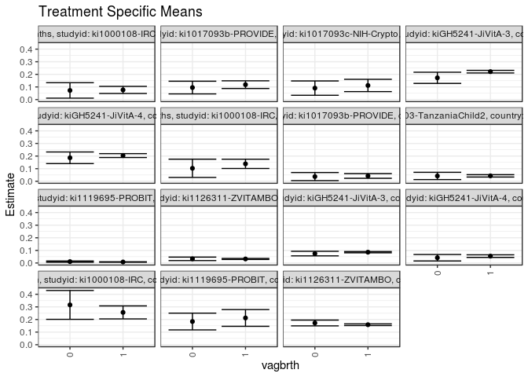

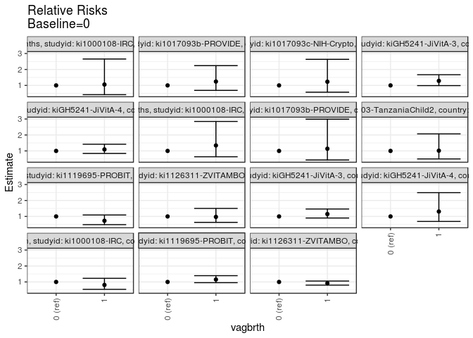

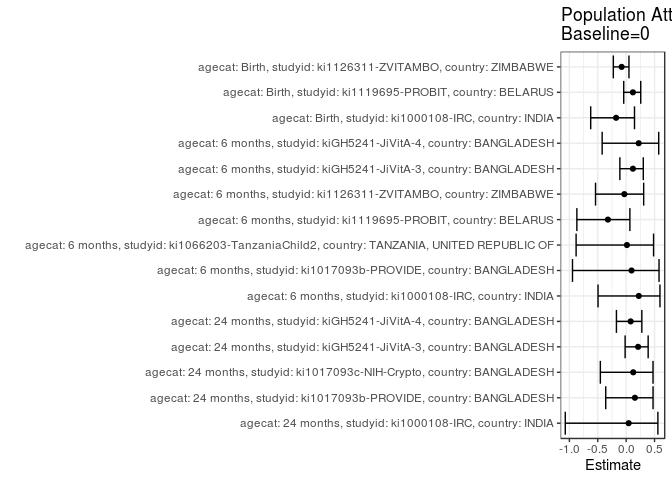

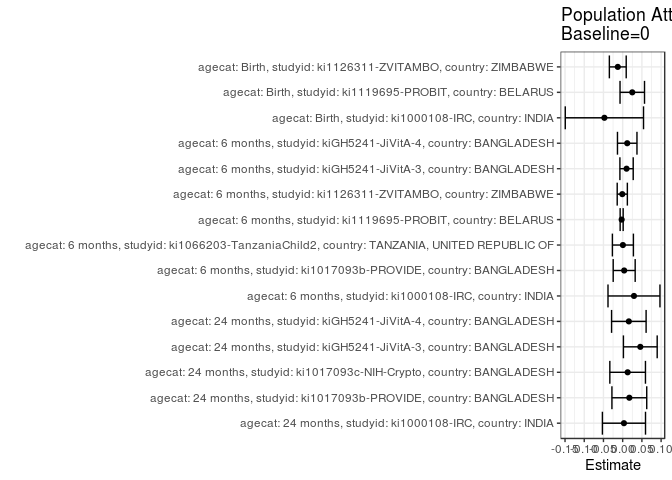

## Results Table

### Parameter: TSM

| agecat | studyid | country | intervention_level | baseline_level | estimate | ci_lower | ci_upper |
| --- | --- | --- | --- | --- | --- | --- | --- |
| Birth | ki1000108-IRC | INDIA | 0 | NA | 0.3157770 | 0.2014302 | 0.4301237 |
| Birth | ki1000108-IRC | INDIA | 1 | NA | 0.2563028 | 0.2047111 | 0.3078946 |
| Birth | ki1119695-PROBIT | BELARUS | 0 | NA | 0.1839431 | 0.1175746 | 0.2503116 |
| Birth | ki1119695-PROBIT | BELARUS | 1 | NA | 0.2121475 | 0.1458244 | 0.2784706 |
| Birth | ki1126311-ZVITAMBO | ZIMBABWE | 0 | NA | 0.1724047 | 0.1494643 | 0.1953451 |
| Birth | ki1126311-ZVITAMBO | ZIMBABWE | 1 | NA | 0.1586514 | 0.1520240 | 0.1652787 |
| 6 months | ki1000108-IRC | INDIA | 0 | NA | 0.1029412 | 0.0306257 | 0.1752567 |
| 6 months | ki1000108-IRC | INDIA | 1 | NA | 0.1382353 | 0.1015032 | 0.1749674 |
| 6 months | ki1017093b-PROVIDE | BANGLADESH | 0 | NA | 0.0373134 | 0.0051958 | 0.0694311 |
| 6 months | ki1017093b-PROVIDE | BANGLADESH | 1 | NA | 0.0424107 | 0.0237336 | 0.0610878 |
| 6 months | ki1066203-TanzaniaChild2 | TANZANIA, UNITED REPUBLIC OF | 0 | NA | 0.0423280 | 0.0136171 | 0.0710390 |
| 6 months | ki1066203-TanzaniaChild2 | TANZANIA, UNITED REPUBLIC OF | 1 | NA | 0.0429752 | 0.0336429 | 0.0523075 |
| 6 months | ki1119695-PROBIT | BELARUS | 0 | NA | 0.0109005 | 0.0061404 | 0.0156606 |
| 6 months | ki1119695-PROBIT | BELARUS | 1 | NA | 0.0079296 | 0.0063537 | 0.0095055 |
| 6 months | ki1126311-ZVITAMBO | ZIMBABWE | 0 | NA | 0.0329808 | 0.0191900 | 0.0467716 |
| 6 months | ki1126311-ZVITAMBO | ZIMBABWE | 1 | NA | 0.0320197 | 0.0280168 | 0.0360226 |
| 6 months | kiGH5241-JiVitA-3 | BANGLADESH | 0 | NA | 0.0746505 | 0.0566539 | 0.0926470 |
| 6 months | kiGH5241-JiVitA-3 | BANGLADESH | 1 | NA | 0.0857511 | 0.0808240 | 0.0906781 |
| 6 months | kiGH5241-JiVitA-4 | BANGLADESH | 0 | NA | 0.0416840 | 0.0160807 | 0.0672874 |
| 6 months | kiGH5241-JiVitA-4 | BANGLADESH | 1 | NA | 0.0545629 | 0.0442831 | 0.0648427 |
| 24 months | ki1000108-IRC | INDIA | 0 | NA | 0.0724638 | 0.0112173 | 0.1337102 |
| 24 months | ki1000108-IRC | INDIA | 1 | NA | 0.0764706 | 0.0481884 | 0.1047528 |
| 24 months | ki1017093b-PROVIDE | BANGLADESH | 0 | NA | 0.0951404 | 0.0447295 | 0.1455512 |
| 24 months | ki1017093b-PROVIDE | BANGLADESH | 1 | NA | 0.1182183 | 0.0878801 | 0.1485564 |
| 24 months | ki1017093c-NIH-Crypto | BANGLADESH | 0 | NA | 0.0909091 | 0.0341710 | 0.1476472 |
| 24 months | ki1017093c-NIH-Crypto | BANGLADESH | 1 | NA | 0.1118012 | 0.0630315 | 0.1605710 |
| 24 months | kiGH5241-JiVitA-3 | BANGLADESH | 0 | NA | 0.1723592 | 0.1280877 | 0.2166308 |
| 24 months | kiGH5241-JiVitA-3 | BANGLADESH | 1 | NA | 0.2214125 | 0.2110076 | 0.2318174 |
| 24 months | kiGH5241-JiVitA-4 | BANGLADESH | 0 | NA | 0.1863000 | 0.1401130 | 0.2324870 |
| 24 months | kiGH5241-JiVitA-4 | BANGLADESH | 1 | NA | 0.2037503 | 0.1883846 | 0.2191160 |

### Parameter: E(Y)

| agecat | studyid | country | intervention_level | baseline_level | estimate | ci_lower | ci_upper |
| --- | --- | --- | --- | --- | --- | --- | --- |
| Birth | ki1000108-IRC | INDIA | NA | NA | 0.2682216 | 0.2212677 | 0.3151755 |
| Birth | ki1119695-PROBIT | BELARUS | NA | NA | 0.2089120 | 0.1435514 | 0.2742726 |
| Birth | ki1126311-ZVITAMBO | ZIMBABWE | NA | NA | 0.1596816 | 0.1533387 | 0.1660245 |
| 6 months | ki1000108-IRC | INDIA | NA | NA | 0.1323529 | 0.0994307 | 0.1652752 |
| 6 months | ki1017093b-PROVIDE | BANGLADESH | NA | NA | 0.0412371 | 0.0250690 | 0.0574052 |
| 6 months | ki1066203-TanzaniaChild2 | TANZANIA, UNITED REPUBLIC OF | NA | NA | 0.0429142 | 0.0340389 | 0.0517895 |
| 6 months | ki1119695-PROBIT | BELARUS | NA | NA | 0.0082503 | 0.0066012 | 0.0098994 |
| 6 months | ki1126311-ZVITAMBO | ZIMBABWE | NA | NA | 0.0319629 | 0.0281547 | 0.0357711 |
| 6 months | kiGH5241-JiVitA-3 | BANGLADESH | NA | NA | 0.0847650 | 0.0799741 | 0.0895560 |
| 6 months | kiGH5241-JiVitA-4 | BANGLADESH | NA | NA | 0.0535010 | 0.0438560 | 0.0631459 |
| 24 months | ki1000108-IRC | INDIA | NA | NA | 0.0757946 | 0.0501131 | 0.1014762 |
| 24 months | ki1017093b-PROVIDE | BANGLADESH | NA | NA | 0.1124567 | 0.0866788 | 0.1382347 |
| 24 months | ki1017093c-NIH-Crypto | BANGLADESH | NA | NA | 0.1038462 | 0.0666939 | 0.1409984 |
| 24 months | kiGH5241-JiVitA-3 | BANGLADESH | NA | NA | 0.2182350 | 0.2083008 | 0.2281691 |
| 24 months | kiGH5241-JiVitA-4 | BANGLADESH | NA | NA | 0.2023453 | 0.1877652 | 0.2169254 |

### Parameter: RR

| agecat | studyid | country | intervention_level | baseline_level | estimate | ci_lower | ci_upper |
| --- | --- | --- | --- | --- | --- | --- | --- |
| Birth | ki1000108-IRC | INDIA | 0 | 0 | 1.0000000 | 1.0000000 | 1.000000 |
| Birth | ki1000108-IRC | INDIA | 1 | 0 | 0.8116578 | 0.5360424 | 1.228986 |
| Birth | ki1119695-PROBIT | BELARUS | 0 | 0 | 1.0000000 | 1.0000000 | 1.000000 |
| Birth | ki1119695-PROBIT | BELARUS | 1 | 0 | 1.1533319 | 0.9545670 | 1.393485 |
| Birth | ki1126311-ZVITAMBO | ZIMBABWE | 0 | 0 | 1.0000000 | 1.0000000 | 1.000000 |
| Birth | ki1126311-ZVITAMBO | ZIMBABWE | 1 | 0 | 0.9202265 | 0.8004790 | 1.057888 |
| 6 months | ki1000108-IRC | INDIA | 0 | 0 | 1.0000000 | 1.0000000 | 1.000000 |
| 6 months | ki1000108-IRC | INDIA | 1 | 0 | 1.3428571 | 0.6336429 | 2.845870 |
| 6 months | ki1017093b-PROVIDE | BANGLADESH | 0 | 0 | 1.0000000 | 1.0000000 | 1.000000 |
| 6 months | ki1017093b-PROVIDE | BANGLADESH | 1 | 0 | 1.1366071 | 0.4322192 | 2.988937 |
| 6 months | ki1066203-TanzaniaChild2 | TANZANIA, UNITED REPUBLIC OF | 0 | 0 | 1.0000000 | 1.0000000 | 1.000000 |
| 6 months | ki1066203-TanzaniaChild2 | TANZANIA, UNITED REPUBLIC OF | 1 | 0 | 1.0152893 | 0.4980591 | 2.069659 |
| 6 months | ki1119695-PROBIT | BELARUS | 0 | 0 | 1.0000000 | 1.0000000 | 1.000000 |
| 6 months | ki1119695-PROBIT | BELARUS | 1 | 0 | 0.7274523 | 0.4847283 | 1.091719 |
| 6 months | ki1126311-ZVITAMBO | ZIMBABWE | 0 | 0 | 1.0000000 | 1.0000000 | 1.000000 |
| 6 months | ki1126311-ZVITAMBO | ZIMBABWE | 1 | 0 | 0.9708611 | 0.6275211 | 1.502055 |
| 6 months | kiGH5241-JiVitA-3 | BANGLADESH | 0 | 0 | 1.0000000 | 1.0000000 | 1.000000 |
| 6 months | kiGH5241-JiVitA-3 | BANGLADESH | 1 | 0 | 1.1487011 | 0.9014799 | 1.463720 |
| 6 months | kiGH5241-JiVitA-4 | BANGLADESH | 0 | 0 | 1.0000000 | 1.0000000 | 1.000000 |
| 6 months | kiGH5241-JiVitA-4 | BANGLADESH | 1 | 0 | 1.3089639 | 0.6878077 | 2.491083 |
| 24 months | ki1000108-IRC | INDIA | 0 | 0 | 1.0000000 | 1.0000000 | 1.000000 |
| 24 months | ki1000108-IRC | INDIA | 1 | 0 | 1.0552941 | 0.4194722 | 2.654874 |
| 24 months | ki1017093b-PROVIDE | BANGLADESH | 0 | 0 | 1.0000000 | 1.0000000 | 1.000000 |
| 24 months | ki1017093b-PROVIDE | BANGLADESH | 1 | 0 | 1.2425671 | 0.6893468 | 2.239762 |
| 24 months | ki1017093c-NIH-Crypto | BANGLADESH | 0 | 0 | 1.0000000 | 1.0000000 | 1.000000 |
| 24 months | ki1017093c-NIH-Crypto | BANGLADESH | 1 | 0 | 1.2298137 | 0.5743075 | 2.633505 |
| 24 months | kiGH5241-JiVitA-3 | BANGLADESH | 0 | 0 | 1.0000000 | 1.0000000 | 1.000000 |
| 24 months | kiGH5241-JiVitA-3 | BANGLADESH | 1 | 0 | 1.2845991 | 0.9880727 | 1.670115 |
| 24 months | kiGH5241-JiVitA-4 | BANGLADESH | 0 | 0 | 1.0000000 | 1.0000000 | 1.000000 |
| 24 months | kiGH5241-JiVitA-4 | BANGLADESH | 1 | 0 | 1.0936678 | 0.8434227 | 1.418161 |

### Parameter: PAR

| agecat | studyid | country | intervention_level | baseline_level | estimate | ci_lower | ci_upper |
| --- | --- | --- | --- | --- | --- | --- | --- |
| Birth | ki1000108-IRC | INDIA | 0 | NA | -0.0475554 | -0.1493688 | 0.0542580 |
| Birth | ki1119695-PROBIT | BELARUS | 0 | NA | 0.0249689 | -0.0068829 | 0.0568207 |
| Birth | ki1126311-ZVITAMBO | ZIMBABWE | 0 | NA | -0.0127232 | -0.0346492 | 0.0092028 |
| 6 months | ki1000108-IRC | INDIA | 0 | NA | 0.0294118 | -0.0381917 | 0.0970152 |
| 6 months | ki1017093b-PROVIDE | BANGLADESH | 0 | NA | 0.0039237 | -0.0246761 | 0.0325234 |
| 6 months | ki1066203-TanzaniaChild2 | TANZANIA, UNITED REPUBLIC OF | 0 | NA | 0.0005861 | -0.0267563 | 0.0279285 |
| 6 months | ki1119695-PROBIT | BELARUS | 0 | NA | -0.0026502 | -0.0065782 | 0.0012779 |
| 6 months | ki1126311-ZVITAMBO | ZIMBABWE | 0 | NA | -0.0010178 | -0.0142157 | 0.0121800 |
| 6 months | kiGH5241-JiVitA-3 | BANGLADESH | 0 | NA | 0.0101146 | -0.0071955 | 0.0274247 |
| 6 months | kiGH5241-JiVitA-4 | BANGLADESH | 0 | NA | 0.0118170 | -0.0135494 | 0.0371833 |
| 24 months | ki1000108-IRC | INDIA | 0 | NA | 0.0033309 | -0.0527495 | 0.0594112 |
| 24 months | ki1017093b-PROVIDE | BANGLADESH | 0 | NA | 0.0173164 | -0.0279629 | 0.0625957 |
| 24 months | ki1017093c-NIH-Crypto | BANGLADESH | 0 | NA | 0.0129371 | -0.0334089 | 0.0592830 |
| 24 months | kiGH5241-JiVitA-3 | BANGLADESH | 0 | NA | 0.0458757 | 0.0019474 | 0.0898040 |
| 24 months | kiGH5241-JiVitA-4 | BANGLADESH | 0 | NA | 0.0160453 | -0.0288707 | 0.0609613 |

### Parameter: PAF

| agecat | studyid | country | intervention_level | baseline_level | estimate | ci_lower | ci_upper |
| --- | --- | --- | --- | --- | --- | --- | --- |
| Birth | ki1000108-IRC | INDIA | 0 | NA | -0.1772988 | -0.6247127 | 0.1469060 |
| Birth | ki1119695-PROBIT | BELARUS | 0 | NA | 0.1195187 | -0.0429429 | 0.2566733 |
| Birth | ki1126311-ZVITAMBO | ZIMBABWE | 0 | NA | -0.0796783 | -0.2260759 | 0.0492389 |
| 6 months | ki1000108-IRC | INDIA | 0 | NA | 0.2222222 | -0.4955071 | 0.5954962 |
| 6 months | ki1017093b-PROVIDE | BANGLADESH | 0 | NA | 0.0951493 | -0.9453954 | 0.5791319 |
| 6 months | ki1066203-TanzaniaChild2 | TANZANIA, UNITED REPUBLIC OF | 0 | NA | 0.0136582 | -0.8817567 | 0.4829989 |
| 6 months | ki1119695-PROBIT | BELARUS | 0 | NA | -0.3212221 | -0.8682555 | 0.0656375 |
| 6 months | ki1126311-ZVITAMBO | ZIMBABWE | 0 | NA | -0.0318447 | -0.5395330 | 0.3084244 |
| 6 months | kiGH5241-JiVitA-3 | BANGLADESH | 0 | NA | 0.1193248 | -0.1107122 | 0.3017193 |
| 6 months | kiGH5241-JiVitA-4 | BANGLADESH | 0 | NA | 0.2208737 | -0.4227843 | 0.5733452 |
| 24 months | ki1000108-IRC | INDIA | 0 | NA | 0.0439458 | -1.0726677 | 0.5590033 |
| 24 months | ki1017093b-PROVIDE | BANGLADESH | 0 | NA | 0.1539827 | -0.3599288 | 0.4736891 |
| 24 months | ki1017093c-NIH-Crypto | BANGLADESH | 0 | NA | 0.1245791 | -0.4545902 | 0.4731425 |
| 24 months | kiGH5241-JiVitA-3 | BANGLADESH | 0 | NA | 0.2102125 | -0.0183776 | 0.3874921 |
| 24 months | kiGH5241-JiVitA-4 | BANGLADESH | 0 | NA | 0.0792968 | -0.1712814 | 0.2762676 |